# Project 1

Deeksha Tomar

2024-09-13

Read in `chocolate` data.

```r
library("here")
chocolate <- readRDS(here("data", "chocolate.RDS"))
```

Explore the `chocolate` data.

```r
library("tidyverse")
glimpse(chocolate)
```

```
## Rows: 2,530
## Columns: 10
## $ ref                              <dbl> 2454, 2458, 2454, 2542, 2546, 2546, 2…
## $ company_manufacturer             <chr> "5150", "5150", "5150", "5150", "5150…
## $ company_location                 <chr> "U.S.A.", "U.S.A.", "U.S.A.", "U.S.A.…
## $ review_date                      <dbl> 2019, 2019, 2019, 2021, 2021, 2021, 2…
## $ country_of_bean_origin           <chr> "Tanzania", "Dominican Republic", "Ma…
## $ specific_bean_origin_or_bar_name <chr> "Kokoa Kamili, batch 1", "Zorzal, bat…
## $ cocoa_percent                    <chr> "76%", "76%", "76%", "68%", "72%", "8…
## $ ingredients                      <chr> "3- B,S,C", "3- B,S,C", "3- B,S,C", "…
## $ most_memorable_characteristics   <chr> "rich cocoa, fatty, bready", "cocoa, …
## $ rating                           <dbl> 3.25, 3.50, 3.75, 3.00, 3.00, 3.25, 3…
```

## Explore Data

### Solution 1

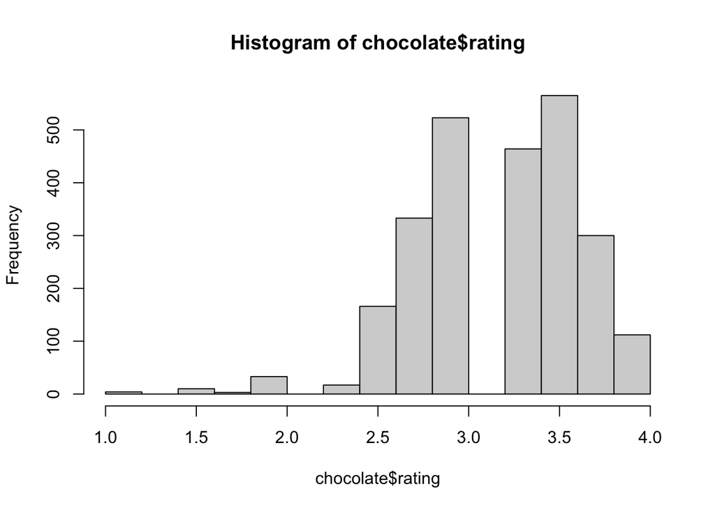

```r
library(dplyr)
library(ggplot2)
hist(chocolate$rating)
```

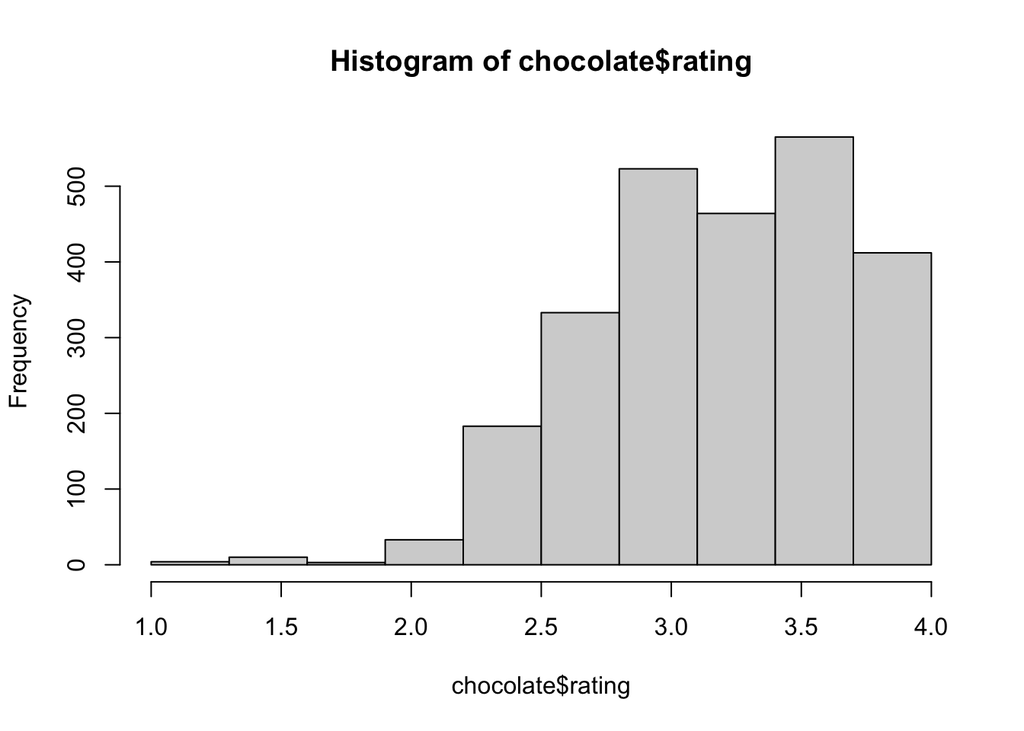

```r
hist(chocolate$rating, breaks = seq(min(chocolate$rating), max(chocolate$rating), length.out = 11))
```

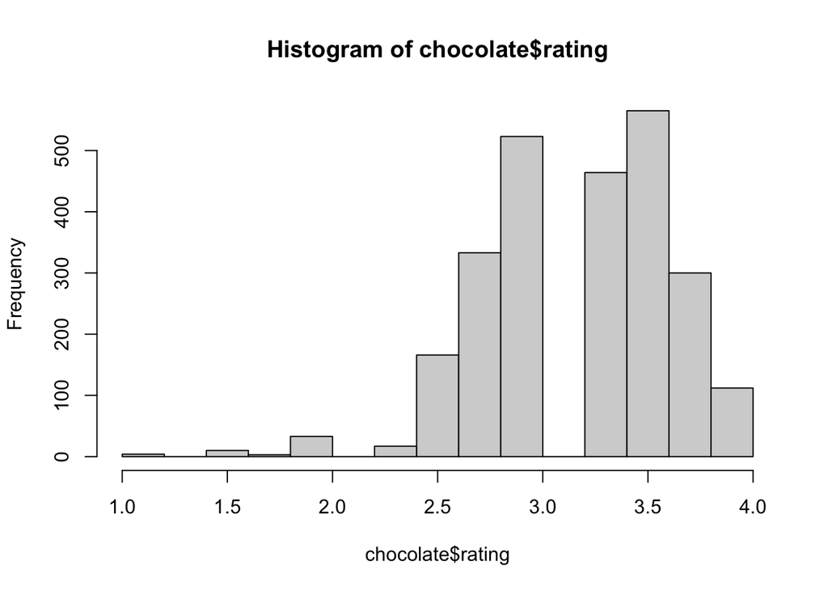

```r
hist(chocolate$rating, breaks = seq(min(chocolate$rating), max(chocolate$rating), length.out = 16))
```

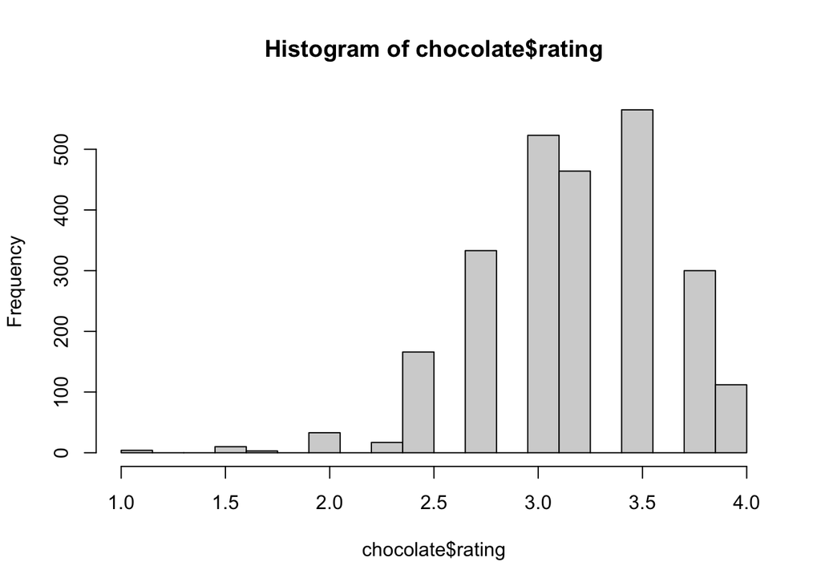

```r
hist(chocolate$rating, breaks = seq(min(chocolate$rating), max(chocolate$rating), length.out = 21))
```

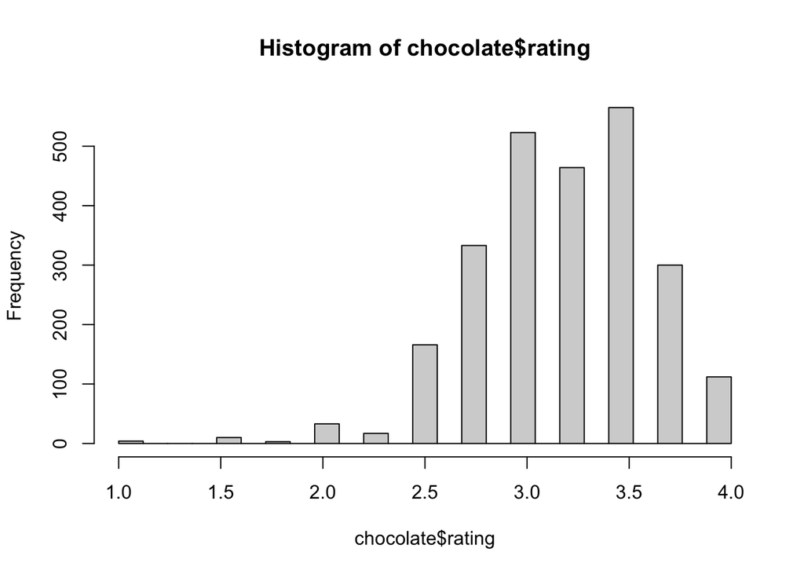

```r
hist(chocolate$rating, breaks = seq(min(chocolate$rating), max(chocolate$rating), length.out = 26))
```

```r
head(chocolate, 5)
```

```
## # A tibble: 5 × 10
##     ref company_manufacturer company_location review_date country_of_bean_origin
##   <dbl> <chr>                <chr>                  <dbl> <chr>
## 1  2454 5150                 U.S.A.                  2019 Tanzania
## 2  2458 5150                 U.S.A.                  2019 Dominican Republic
## 3  2454 5150                 U.S.A.                  2019 Madagascar
## 4  2542 5150                 U.S.A.                  2021 Fiji
## 5  2546 5150                 U.S.A.                  2021 Venezuela
## # ℹ 5 more variables: specific_bean_origin_or_bar_name <chr>,
## #   cocoa_percent <chr>, ingredients <chr>,
## #   most_memorable_characteristics <chr>, rating <dbl>
```

According to me, histogram with lesser number of bins is more readable and there are no missing bins in the histogram that has 10 bins.

### Solution 2

```r
table(chocolate$country_of_bean_origin)
```

```
##
##             Australia                Belize                 Blend
##                     3                    76                   156
##               Bolivia                Brazil                 Burma
##                    80                    78                     1
##              Cameroon                 China              Colombia
##                     3                     1                    79
##                 Congo            Costa Rica                  Cuba
##                    11                    43                    12
##    Dominican Republic              DR Congo               Ecuador
##                   226                     1                   219
##           El Salvador                  Fiji                 Gabon
##                     6                    16                     1
##                 Ghana               Grenada             Guatemala
##                    41                    19                    62
##                 Haiti              Honduras                 India
##                    30                    25                    35
##             Indonesia           Ivory Coast               Jamaica
##                    20                     7                    24
##               Liberia            Madagascar              Malaysia
##                     3                   177                     8
##            Martinique                Mexico             Nicaragua
##                     1                    55                   100
##               Nigeria                Panama      Papua New Guinea
##                     3                     9                    50
##                  Peru           Philippines              Principe
##                   244                    24                     1
##           Puerto Rico                 Samoa              Sao Tome
##                     7                     3                    14
##   Sao Tome & Principe          Sierra Leone       Solomon Islands
##                     2                     4                    10
##             Sri Lanka             St. Lucia St.Vincent-Grenadines
##                     2                    10                     1
##              Sulawesi               Sumatra              Suriname
##                     1                     1                     1
##                Taiwan              Tanzania              Thailand
##                     2                    79                     5
##                Tobago                  Togo              Trinidad
##                     2                     3                    42
##                U.S.A.                Uganda               Vanuatu
##                    33                    19                    13
##             Venezuela               Vietnam
##                   253                    73
```

### Solution 3

```r
country_Ecuador <- filter(chocolate, country_of_bean_origin == "Ecuador")
sd(country_Ecuador$rating)
```

```
## [1] 0.5122678
```

```r
length(country_Ecuador$rating)
```

```
## [1] 219
```

```r
mean(country_Ecuador$rating)
```

```
## [1] 3.164384
```

```r
summary_stats <- data.frame(mean = country_Ecuador$rating, sd = country_Ecuador$rating, total = country_Ecuador$rating)
print(summary_stats)
```

```
##     mean   sd total
## 1   3.75 3.75  3.75
## 2   2.75 2.75  2.75
## 3   3.00 3.00  3.00
## 4   3.50 3.50  3.50
## 5   2.75 2.75  2.75
## 6   4.00 4.00  4.00
## 7   2.75 2.75  2.75
## 8   2.75 2.75  2.75
## 9   3.00 3.00  3.00
## 10  2.75 2.75  2.75
## 11  3.50 3.50  3.50
## 12  3.75 3.75  3.75
## 13  3.25 3.25  3.25
## 14  3.25 3.25  3.25
```

[output cut: 205 more lines]

### solution 4

```r
country_Ecuador <- filter(chocolate, country_of_bean_origin == "Ecuador")
best_chocolate_location <- country_Ecuador %>%
  group_by(company_location) %>%
  summarize(mean_rating = mean(rating, na.rm = TRUE)) %>%
  arrange(desc(mean_rating))

print(best_chocolate_location)
```

```
## # A tibble: 25 × 2
##    company_location mean_rating
##    <chr>                  <dbl>
##  1 Australia               3.81
##  2 Switzerland             3.75
##  3 New Zealand             3.62
##  4 Hungary                 3.5
##  5 Israel                  3.5
##  6 Netherlands             3.5
##  7 Singapore               3.5
##  8 South Korea             3.33
##  9 Canada                  3.28
## 10 U.S.A.                  3.26
## # ℹ 15 more rows
```

Australia has the highest ratings on average.

### Solution 5

```r
top_countries <- aggregate(rating ~ country_of_bean_origin, data = chocolate, FUN = mean, na.rm = TRUE)
top_countries <- top_countries[order(-top_countries$rating), ][1:3, ]
print(top_countries)
```

```
##    country_of_bean_origin rating
## 55                 Tobago  3.625
## 8                   China  3.500
## 43    Sao Tome & Principe  3.500
```

### Solution 6

```r
filtered_data <- filter(chocolate, country_of_bean_origin %in% names(which(table(chocolate$country_of_bean_origin) >= 10)))

countries_10_or_more <- aggregate(rating ~ country_of_bean_origin, data = filtered_data, FUN = mean, na.rm = TRUE)

print(countries_10_or_more)
```

```
##    country_of_bean_origin   rating
## 1                  Belize 3.233553
## 2                   Blend 3.038462
## 3                 Bolivia 3.181250
## 4                  Brazil 3.262821
## 5                Colombia 3.196203
## 6                   Congo 3.318182
## 7              Costa Rica 3.151163
## 8                    Cuba 3.291667
## 9      Dominican Republic 3.215708
## 10                Ecuador 3.164384
## 11                   Fiji 3.062500
## 12                  Ghana 3.134146
## 13                Grenada 3.026316
## 14              Guatemala 3.258065
```

[output cut: 21 more lines]

```r
sorted_countries <- countries_10_or_more[order(-countries_10_or_more$rating), ]
top_3_countries <- head(sorted_countries, 3)
print(top_3_countries)
```

```
##    country_of_bean_origin   rating
## 27        Solomon Islands 3.450000
## 6                   Congo 3.318182
## 8                    Cuba 3.291667
```

### Solution 7

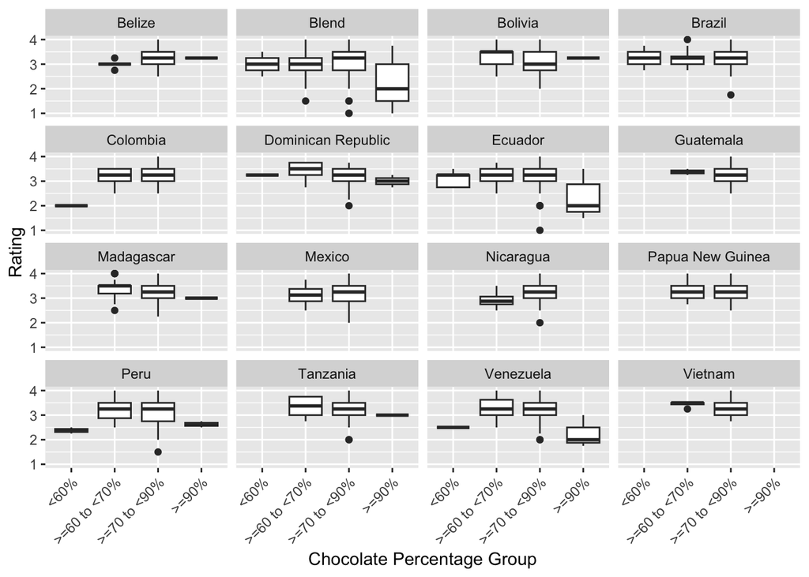

```r
library(dplyr)

# Count the number of reviews per country
country_counts <- chocolate %>%
  count(country_of_bean_origin)

# Filter the dataset to include only countries with at least 50 reviews
valid_countries <- country_counts %>%
  filter(n >= 50) %>%
  pull(country_of_bean_origin)

# Filter the original dataset to include only reviews from valid countries
filtered_chocolate <- chocolate %>%
  filter(country_of_bean_origin %in% valid_countries)
# Convert percentage to numeric and create groups
filtered_chocolate <- filtered_chocolate %>%
  mutate(
    cocoa_percent = as.numeric(sub("%", "", cocoa_percent)),  # Remove "%" and convert to numeric
    percentage_group = case_when(
      cocoa_percent < 60 ~ "<60%",
      cocoa_percent >= 60 & cocoa_percent < 70 ~ ">=60 to <70%",
      cocoa_percent >= 70 & cocoa_percent < 90 ~ ">=70 to <90%",
      cocoa_percent >= 90 ~ ">=90%" ) )
library(forcats)

# Re-order the percentage groups
filtered_chocolate <- filtered_chocolate %>%
  mutate(percentage_group = fct_relevel(percentage_group, "<60%", ">=60 to <70%", ">=70 to <90%", ">=90%"))
library(ggplot2)

# Create the boxplots
ggplot(filtered_chocolate, aes(x = percentage_group, y = rating)) +
  geom_boxplot() +
  facet_wrap(~ country_of_bean_origin) +
  labs(x = "Chocolate Percentage Group", y = "Rating") +
  theme(axis.text.x = element_text(angle = 45, hjust = 1))
```

```r
# Calculate average rating for each percentage group
average_ratings <- filtered_chocolate %>%
  group_by(percentage_group) %>%
  summarize(mean_rating = mean(rating, na.rm = TRUE))

# Display the result
print(average_ratings)
```

```
## # A tibble: 4 × 2
##   percentage_group mean_rating
##   <fct>                  <dbl>
## 1 <60%                    2.96
## 2 >=60 to <70%            3.25
## 3 >=70 to <90%            3.22
## 4 >=90%                   2.49
```

### PART 2

```r
options(repos = c(CRAN = "https://cloud.r-project.org"))
if(!require(gapminder)) {
  install.packages("gapminder")
}
library(gapminder)
install.packages("gapminder")
library(gapminder)

gapminder_continents <- gapminder %>%
  select(country, continent) %>%
  distinct()
chocolate_with_continent <- filtered_chocolate %>%
  left_join(gapminder_continents, by = c("country_of_bean_origin" = "country"))
head(chocolate_with_continent)
```

```
## # A tibble: 6 × 12
##     ref company_manufacturer company_location review_date country_of_bean_origin
##   <dbl> <chr>                <chr>                  <dbl> <chr>
## 1  2454 5150                 U.S.A.                  2019 Tanzania
## 2  2458 5150                 U.S.A.                  2019 Dominican Republic
## 3  2454 5150                 U.S.A.                  2019 Madagascar
## 4  2546 5150                 U.S.A.                  2021 Venezuela
## 5   797 A. Morin             France                  2012 Bolivia
## 6   797 A. Morin             France                  2012 Peru
## # ℹ 7 more variables: specific_bean_origin_or_bar_name <chr>,
## #   cocoa_percent <dbl>, ingredients <chr>,
## #   most_memorable_characteristics <chr>, rating <dbl>, percentage_group <fct>,
## #   continent <fct>
```

```r
library(dplyr)
country_counts <- chocolate_with_continent %>%
  group_by(country_of_bean_origin) %>%
  summarise(total_reviews = n())
chocolate_filtered <- chocolate_with_continent %>%
  filter(country_of_bean_origin %in% country_counts$country_of_bean_origin[country_counts$total_reviews >= 10] &
         country_of_bean_origin != "Blend")
table(chocolate_with_continent$country_of_bean_origin)
```

```
##
##             Belize              Blend            Bolivia             Brazil
##                 76                156                 80                 78
##           Colombia Dominican Republic            Ecuador          Guatemala
##                 79                226                219                 62
##         Madagascar             Mexico          Nicaragua   Papua New Guinea
##                177                 55                100                 50
##               Peru           Tanzania          Venezuela            Vietnam
##                244                 79                253                 73
```

```r
sum(is.na(chocolate_filtered$continent))
```

```
## [1] 126
```

```r
table(chocolate_filtered$country_of_bean_origin)
```

```
##
##             Belize            Bolivia             Brazil           Colombia
##                 76                 80                 78                 79
## Dominican Republic            Ecuador          Guatemala         Madagascar
##                226                219                 62                177
##             Mexico          Nicaragua   Papua New Guinea               Peru
##                 55                100                 50                244
##           Tanzania          Venezuela            Vietnam
##                 79                253                 73
```

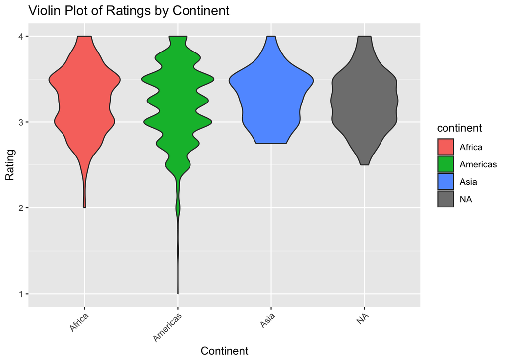

```r
library(ggplot2)

# Violin plot of ratings by continent
ggplot(chocolate_filtered, aes(x = continent, y = rating, fill = continent)) +
  geom_violin() +
  labs(title = "Violin Plot of Ratings by Continent",
       x = "Continent",
       y = "Rating") +
  theme(axis.text.x = element_text(angle = 45, hjust = 1))
```

## part 3

```r
# Load necessary libraries
library(dplyr)
library(tidyr)
library(stringr)

library("here")
chocolate <- readRDS(here("data", "chocolate.RDS"))
# Create ingredient columns
chocolate <- chocolate %>%
  mutate(beans = ifelse(str_detect(ingredients, "beans"), 1, 0),
         sugar = ifelse(str_detect(ingredients, "sugar"), 1, 0),
         cocoa_butter = ifelse(str_detect(ingredients, "cocoa_butter"), 1, 0),
         vanilla = ifelse(str_detect(ingredients, "vanilla"), 1, 0),
         letchin = ifelse(str_detect(ingredients, "letchin"), 1, 0),
         salt = ifelse(str_detect(ingredients, "salt"), 1, 0))

chocolate<- chocolate %>%
  mutate(
    char_cocoa = ifelse(str_detect(most_memorable_characteristics, "cocoa"), 1, 0),
    char_sweet = ifelse(str_detect(most_memorable_characteristics, "sweet"), 1, 0),
    char_nutty = ifelse(str_detect(most_memorable_characteristics, "nutty"), 1, 0),
    char_creamy = ifelse(str_detect(most_memorable_characteristics, "creamy"), 1, 0),
    char_roasty = ifelse(str_detect(most_memorable_characteristics, "roasty"), 1, 0),
    char_earthy = ifelse(str_detect(most_memorable_characteristics, "earthy"), 1, 0)
  )
mean_characteristics_by_year <- chocolate %>%
  group_by(review_date) %>%
  summarise(
    beans = mean(beans, na.rm = TRUE),
    sugar = mean(sugar, na.rm = TRUE),
    cocoa_butter = mean(cocoa_butter, na.rm = TRUE),
    vanilla = mean(vanilla, na.rm = TRUE),
    letchin = mean(letchin, na.rm = TRUE),
    salt = mean(salt, na.rm = TRUE),
    char_cocoa = mean(char_cocoa, na.rm = TRUE),
    char_sweet = mean(char_sweet, na.rm = TRUE),
    char_nutty = mean(char_nutty, na.rm = TRUE),
    char_creamy = mean(char_creamy, na.rm = TRUE),
    char_roasty = mean(char_roasty, na.rm = TRUE),
    char_earthy = mean(char_earthy, na.rm = TRUE)
  )
long_chocolate <- mean_characteristics_by_year %>%
  pivot_longer(cols = -review_date, names_to = "feature", values_to = "mean_score")

# View the result
print(long_chocolate)
```

```
## # A tibble: 192 × 3
##    review_date feature      mean_score
##          <dbl> <chr>             <dbl>
##  1        2006 beans            0
##  2        2006 sugar            0
##  3        2006 cocoa_butter     0
##  4        2006 vanilla          0
##  5        2006 letchin          0
##  6        2006 salt             0
##  7        2006 char_cocoa       0.210
##  8        2006 char_sweet       0.161
##  9        2006 char_nutty       0.0323
## 10        2006 char_creamy      0.242
## # ℹ 182 more rows
```

### PART 4

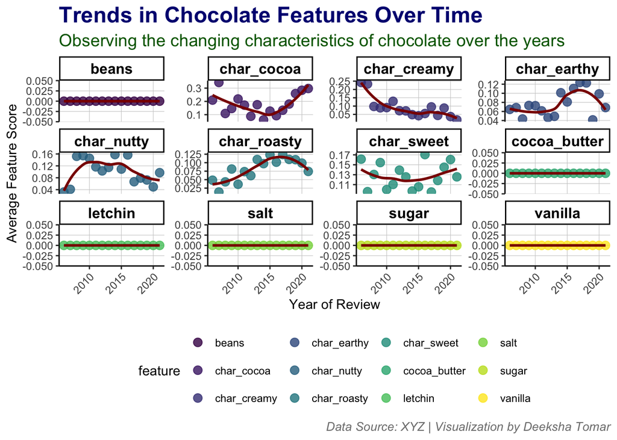

```r
library(ggplot2)
library(tidyr)
library(dplyr)

# Clean data by removing rows with missing values in review_date or mean_score
long_chocolate_clean <- long_chocolate %>%
  drop_na(review_date, mean_score)

# Create the ggplot
ggplot(long_chocolate_clean, aes(x = review_date, y = mean_score)) +
  geom_point(aes(color = feature), size = 3, alpha = 0.8) +  # Scatter points with transparency
  geom_smooth(method = "loess", se = FALSE, color = "darkred", linewidth = 1) +  # Smoother trend line
  facet_wrap(~ feature, scales = "free_y") +  # Separate plots for each feature
  labs(
    title = "Trends in Chocolate Features Over Time",
    subtitle = "Observing the changing characteristics of chocolate over the years",
    caption = "Data Source: XYZ | Visualization by Deeksha Tomar"
  ) +
  xlab("Year of Review") +
  ylab("Average Feature Score") +
  scale_color_viridis_d() +  # Use a color palette that can handle more than 8 categories
  theme_classic() +  # Clean background theme
  theme(
    plot.title = element_text(size = 18, face = "bold", color = "navy"),  # Title formatting
    plot.subtitle = element_text(size = 14, color = "darkgreen"),  # Subtitle formatting
    axis.text.x = element_text(angle = 45, hjust = 1),  # Rotate x-axis labels
    legend.position = "bottom",
    panel.grid.major = element_line(linewidth = 0.2, color = "gray80"),  # Gridline formatting
    strip.text = element_text(size = 12, face = "bold", color = "black"),  # Facet labels formatting
    plot.caption = element_text(size = 10, color = "gray50", face = "italic"),  # Caption formatting
    panel.background = element_rect(fill = "white")  # Background color for plots
  )
```

## Part 5

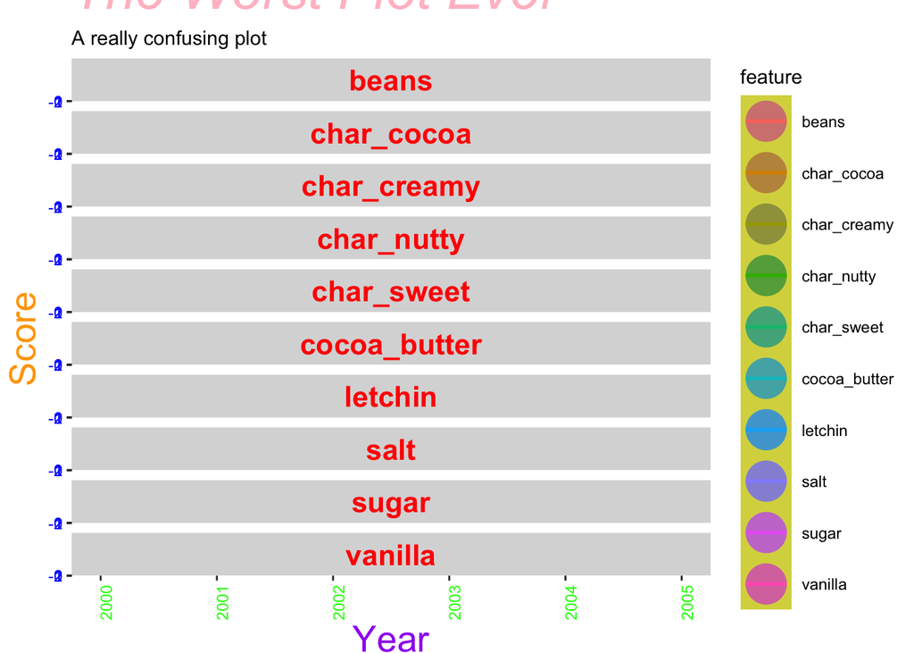

```r
library(ggplot2)
library(dplyr)

# Sample dataset
set.seed(123)
data <- data.frame(
  review_date = rep(2000:2005, each = 10),
  mean_score = runif(60, 0, 1),
  feature = rep(c("beans", "sugar", "cocoa_butter", "vanilla", "letchin", "salt", "char_cocoa", "char_sweet", "char_nutty", "char_creamy"), 6)
)

# Create an awful plot
ggplot(data, aes(x = review_date, y = mean_score, color = feature)) +
  geom_point(size = 10) +  # Large, distracting points
  geom_smooth(method = "lm", se = TRUE) +  # Linear trend with shading
  facet_wrap(~ feature, ncol = 1) +  # One column of facets
  scale_x_continuous(breaks = c(2000, 2001, 2002, 2003, 2004, 2005, 2006, 2007)) +  # Irrelevant x-axis labels
  scale_y_continuous(limits = c(-1, 2)) +  # Arbitrary y-axis limits
  labs(
    title = "The Worst Plot Ever",
    subtitle = "A really confusing plot",
    x = "Year",
    y = "Score",
    caption = "Created by Deeksha Tomar"
  ) +
  theme(
    panel.background = element_rect(fill = "yellow"),  # Bright background color
    plot.title = element_text(size = 30, face = "italic", color = "pink"),  # Large, pink title
    axis.text.x = element_text(angle = 90, color = "green"),  # Vertical, green x-axis labels
    axis.text.y = element_text(color = "blue"),  # Blue y-axis labels
    axis.title.x = element_text(size = 20, color = "purple"),  # Large, purple x-axis title
    axis.title.y = element_text(size = 20, color = "orange"),  # Large, orange y-axis title
    strip.text = element_text(size = 16, face = "bold", color = "red")  # Bold, red facet labels
  )
```

### Part 6

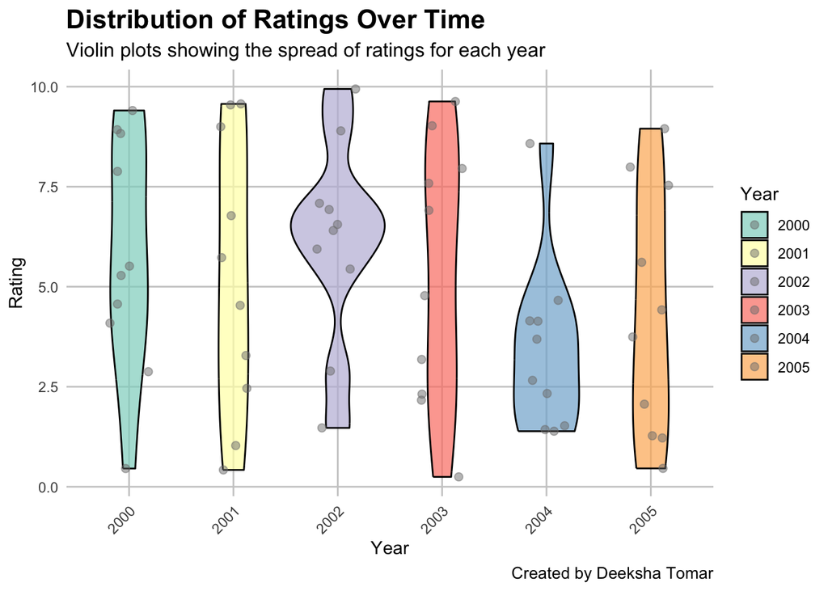

```r
library(ggplot2)
library(dplyr)

# Sample dataset for illustration
set.seed(123)
chocolate <- data.frame(
  review_date = rep(2000:2005, each = 10),
  rating = runif(60, 0, 10)
)

# Improved plot
ggplot(chocolate, aes(x = as.factor(review_date), y = rating, fill = as.factor(review_date))) +
  geom_violin(alpha = 0.7, color = "black") +  # Semi-transparent fill with border
  geom_jitter(width = 0.2, color = "gray50", size = 2, alpha = 0.5) +  # Add jittered points
  labs(
    title = "Distribution of Ratings Over Time",
    subtitle = "Violin plots showing the spread of ratings for each year",
    x = "Year",
    y = "Rating",
    fill = "Year",
    caption = "Created by Deeksha Tomar"
  ) +
  theme_minimal() +
  theme(
    panel.grid.major = element_line(color = "grey80"),  # Light grid lines for readability
    panel.grid.minor = element_blank(),  # Remove minor grid lines
    axis.text.x = element_text(angle = 45, hjust = 1),  # Rotate x-axis labels for readability
    plot.title = element_text(size = 16, face = "bold"),
    plot.subtitle = element_text(size = 12),
    plot.caption = element_text(size = 10)
  ) +
  scale_fill_brewer(palette = "Set3")  # Use a color palette for better fill colors
```

### 7 points:-

## 1 I have added black border in the plots, he border color helps define the shape of each distribution clearly.r (geom_violin(alpha = 0.7, color = “black”))

## 2 I have done Jittering to spread out points along the x-axis to avoid overplotting, and the semi-transparent gray color ensures the points are visible but not too dominant.the color looks subtle. geom_jitter(width = 0.2, color = “gray50”, size = 2, alpha = 0.5)

## 3 Descriptive labels (labs(title, subtitle, x, y, fill, caption)): I have added informative titles, subtitles, and axis labels clarifies the plot’s purpose and content. This helps viewers understand the context and specifics of the data being presented.

## 4 Light grid lines (panel.grid.major = element_line(color = “grey80”)): Added light grid lines to enhance readability of the plot by providing visual reference points without overwhelming the data.

## 5 Removed minor grid lines (panel.grid.minor = element_blank()): Removing minor grid lines reduces visual clutter, making the plot cleaner and easier to interpret.

## 6 Rotated x-axis labels (axis.text.x = element_text(angle = 45, hjust = 1)): Rotated the x-axis labels preventing overlap making them more readable, especially when there are many categories or long labels.

## 7 Used a color palette (scale_fill_brewer(palette = “Set3”)): Applying a color palette from the RColorBrewer package ensures that the fill colors are both distinct and aesthetically pleasing. It helps differentiate between categories clearly.